# IS605-FinalProject

Joseph Elikishvili

May 22, 2017

## IS605 Final

You are to register for Kaggle.com (free) and compete in the House Prices: Advanced Regression Techniques competition. https://www.kaggle.com/c/house-prices-advanced-regression-techniques . I want you to do the following.

Pick one of the quantitative independent variables from the training data set (train.csv) , and define that variable as X. Pick SalePrice as the dependent variable, and define it as Y for the next analysis.

##### We will choose GrossLivingArea as variable X and saleprice as variable y as given.

```r
dataset = read.csv('c:/data/605/train.csv', header = TRUE)
#summary(dataset)
```

### Probability.

Calculate as a minimum the below probabilities a through c. Assume the small letter “x” is estimated as the 4th quartile (this is correct) of the X variable, and the small letter “y” is estimated as the 2nd quartile of the Y variable. Interpret the meaning of all probabilities.

```r
summary(dataset$GrLivArea)
```

```
##    Min. 1st Qu.  Median    Mean 3rd Qu.    Max.
##     334    1130    1464    1515    1777    5642
```

```r
#Assigning value of 1777 based on above
xQ3 = 1777

summary(dataset$SalePrice)
```

```
##    Min. 1st Qu.  Median    Mean 3rd Qu.    Max.
##   34900  130000  163000  180900  214000  755000
```

```r
#Assigning value of 163000 based on above
yQ2 = 163000
```

1. P(X>x | y>y)

```r
#taking a subset where y > Q2
y_subset = subset(dataset, SalePrice > yQ2)

#count number of rows
y_rows = nrow(y_subset)

#find probablity of x>Q3 given y>Q2
Pa = nrow(subset(y_subset, GrLivArea > xQ3))/y_rows
Pa
```

```
## [1] 0.4326923
```

2. P(X>x, Y>y)

```r
#Subset given (x>Q3 and y>Q2)
subsetB = subset(dataset, SalePrice> yQ2 & GrLivArea > xQ3)
Pb = nrow(subsetB)/nrow(dataset)
Pb
```

```
## [1] 0.2157534
```

```r
#taking a subset where y > Q2
y_subset = subset(dataset, SalePrice > yQ2)

#count number of rows
y_rows = nrow(y_subset)

#find probablity of x<Q3 given y>Q2
Pc = nrow(subset(y_subset, GrLivArea < xQ3))/y_rows
Pc
```

```
## [1] 0.5673077
```

```r
# We could have also gotten this by 1- Pa
1-Pa
```

```
## [1] 0.5673077
```

Does splitting the training data in this fashion make them independent? In other words, does P(XY)=P(X)P(Y) or does P(X|Y) = P(X)? Check mathematically, and then evaluate by running a Chi Square test for association. You might have to research this. A Chi Square test for independence (association) will require you to bin the data into logical groups

P(X|Y) = (X>x | Y>y) = 0.4326923 We have calculated this in the example a) above

P(X) = P(X>x) = P(X>xQ3) = 0.25 ( calculated below)

Therefore P(X|Y) != P(X)

```r
x_subset = subset(dataset, GrLivArea > xQ3)
Px = nrow(subset(dataset, GrLivArea > xQ3))/nrow(dataset)
Px
```

```
## [1] 0.25
```

Build Contingency Table and perform a Chi Square test

```r
Con_table <- table(dataset$GrLivArea > xQ3, dataset$SalePrice> yQ2)
Con_table
```

```
##
##         FALSE TRUE
##   FALSE   682  413
##   TRUE     50  315
```

```r
chisq.test(Con_table)
```

```
##
##  Pearson's Chi-squared test with Yates' continuity correction
##
## data:  Con_table
## X-squared = 256.53, df = 1, p-value < 2.2e-16
```

The Chi Square test tests the following hypothesis:

Ho: Data is independent Ha: Data is not independent

The test produces a p-value that is very low so we can safely reject the Null hypotheses and conclude that there is not enough proof to conclude that data is independent

The Chi Square test conforms with our previous conclusion that Gross Living Ares is not independent from Sales Price.

### Descriptive and Inferential Statistics.

Provide univariate descriptive statistics and appropriate plots for both variables. Provide a scatterplot of X and Y. Transform both variables simultaneously using Box-Cox transformations. You might have to research this. Using the transformed variables, run a correlation analysis and interpret. Test the hypothesis that the correlation between these variables is 0 and provide a 99% confidence interval. Discuss the meaning of your analysis.

```r
library(psych)
summary(dataset$GrLivArea)
```

```
##    Min. 1st Qu.  Median    Mean 3rd Qu.    Max.
##     334    1130    1464    1515    1777    5642
```

```r
describe(dataset$SalePrice)
```

```
##    vars    n     mean      sd median  trimmed     mad   min    max  range
## X1    1 1460 180921.2 79442.5 163000 170783.3 56338.8 34900 755000 720100
##    skew kurtosis      se
## X1 1.88      6.5 2079.11
```

```r
describe(dataset$GrLivArea)
```

```
##    vars    n    mean     sd median trimmed    mad min  max range skew
## X1    1 1460 1515.46 525.48   1464 1467.67 483.33 334 5642  5308 1.36
##    kurtosis    se
## X1     4.86 13.75
```

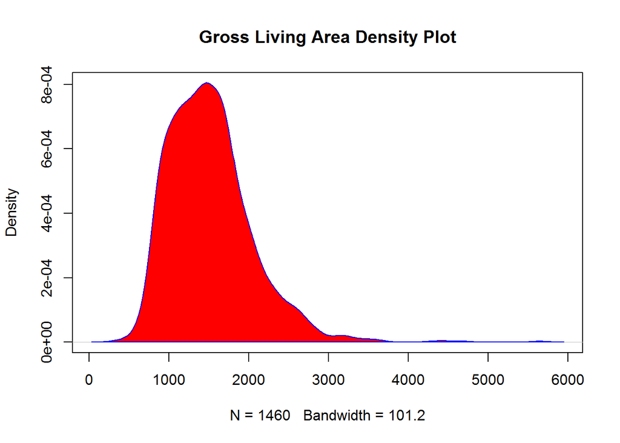

```r
d = density(dataset$GrLivArea)
plot(d, main="Gross Living Area Density Plot")
polygon(d, col="red", border="blue")
```

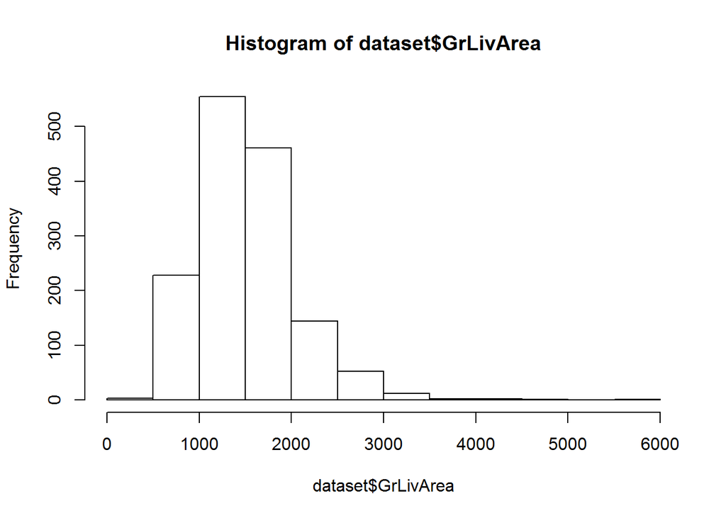

```r
hist(dataset$GrLivArea)
```

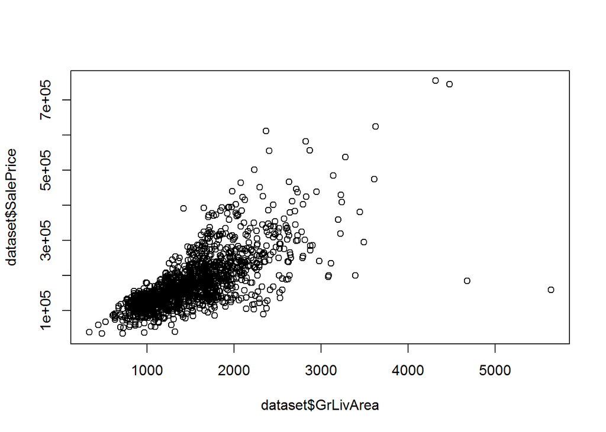

```r
plot(dataset$GrLivArea, dataset$SalePrice)
```

Box-cox

```r
library(MASS)
#Create LM
linm = lm(GrLivArea~SalePrice, data = dataset)
bc = boxcox(linm, lambda=seq(0,1,by=.1))
```

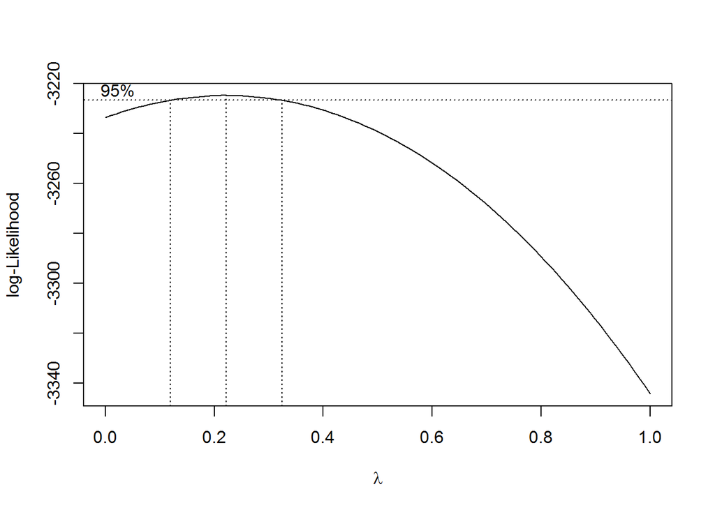

```r
#find the max possible y to point to best lambda estimate
lambda=bc$x[which.max(bc$y)]
lambda
```

```
## [1] 0.2222222
```

```r
describe(dataset$GrLivArea^lambda)
```

```
##    vars    n mean   sd median trimmed  mad  min  max range skew kurtosis
## X1    1 1460 5.04 0.37   5.05    5.03 0.37 3.64 6.82  3.18 0.25     0.46
##      se
## X1 0.01
```

```r
#Apply transformation to variables
t_dataset = data.frame(dataset$GrLivArea^lambda, dataset$SalePrice^lambda)
colnames(t_dataset) <- c("GrLivArea","SalePrice")

head(t_dataset)
```

```
##   GrLivArea SalePrice
## 1  5.229300  15.20630
## 2  4.887922  14.74481
## 3  5.280078  15.44288
## 4  5.234050  13.91823
## 5  5.529334  15.83223
## 6  4.971458  13.98396
```

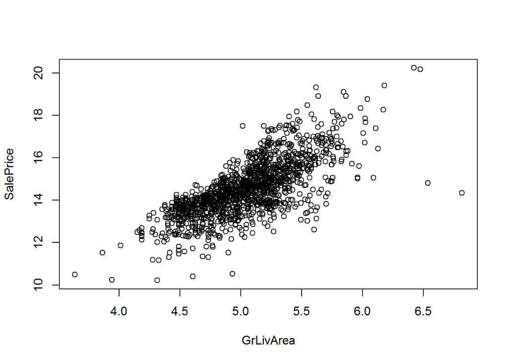

```r
plot(t_dataset)
```

```r
#correlation

cor(t_dataset)
```

```
##           GrLivArea SalePrice
## GrLivArea  1.000000  0.730013
## SalePrice  0.730013  1.000000
```

```r
cor.test(t_dataset$GrLivArea, t_dataset$SalePrice, conf.level = 0.99)
```

```
##
##  Pearson's product-moment correlation
##
## data:  t_dataset$GrLivArea and t_dataset$SalePrice
## t = 40.786, df = 1458, p-value < 2.2e-16
## alternative hypothesis: true correlation is not equal to 0
## 99 percent confidence interval:
##  0.6969131 0.7600093
## sample estimates:
##      cor
## 0.730013
```

Based on above we see that p-value is pretty small so we can reject the Null Hypoteses and state that we do no have enough evidence to suggest that correlation is equal to 0. So based on that it is safe to state that correlation is not 0.

### Linear Algebra and Correlation.

Invert your correlation matrix from the previous section. (This is known as the precision matrix and contains variance inflation factors on the diagonal.) Multiply the correlation matrix by the precision matrix, and then multiply the precision matrix by the correlation matrix.

```r
#library('corrplot')
#corrplot(t_dataset, method = "circle")

cor_M = cor(t_dataset)
cor_M
```

```
##           GrLivArea SalePrice
## GrLivArea  1.000000  0.730013
## SalePrice  0.730013  1.000000
```

```r
pres_M = solve(cor_M)
pres_M
```

```
##           GrLivArea SalePrice
## GrLivArea  2.140956 -1.562926
## SalePrice -1.562926  2.140956
```

```r
cor_M %*% pres_M
```

```
##               GrLivArea SalePrice
## GrLivArea  1.000000e+00         0
## SalePrice -2.220446e-16         1
```

```r
pres_M %*% cor_M
```

```
##               GrLivArea SalePrice
## GrLivArea  1.000000e+00         0
## SalePrice -2.220446e-16         1
```

### Calculus-Based Probability & Statistics.

Many times, it makes sense to fit a closed form distribution to data. For your non-transformed independent variable ( X ), location shift it so that the minimum value is above zero. Then load the MASS package and run fitdistr to fit a density function of your choice. (See https://stat.ethz.ch/R-manual/R-devel/library/MASS/html/fitdistr.html ). Find the optimal value of the parameters for this distribution, and then take 1000 samples from this distribution (e.g., rexp(1000, ???) for an exponential). Plot a histogram and compare it with a histogram of your non-transformed original variable.

The Data we are using is always above 0 so we will not be using location shift.

```r
library(MASS)

fit_exp = fitdistr(dataset$GrLivArea, "exponential")

fit_exp
```

```
##        rate
##   6.598640e-04
##  (1.726943e-05)
```

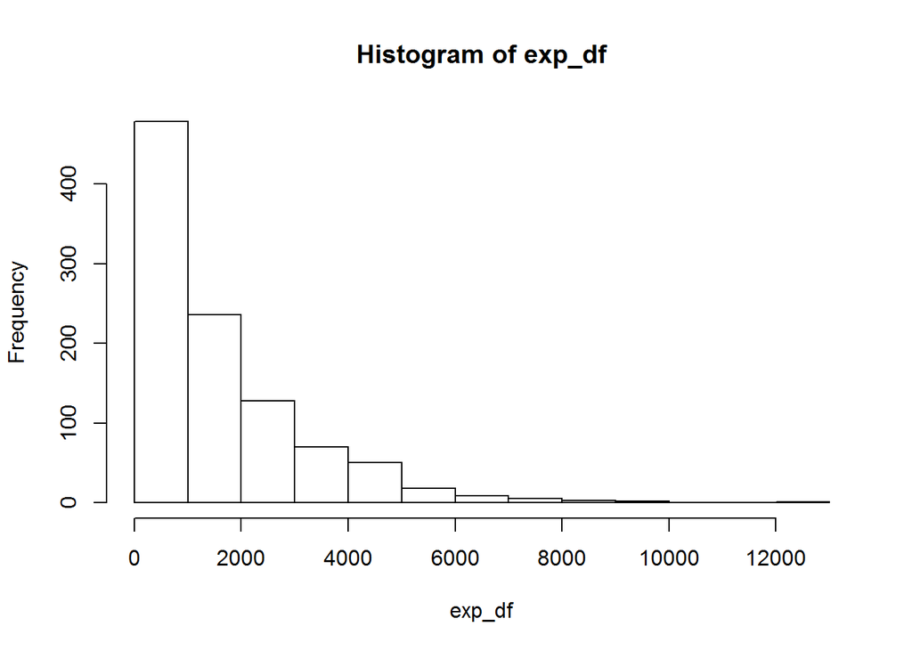

```r
lambda_exp = fit_exp$estimate

exp_df = rexp(1000, lambda_exp)

#Histogram of Samples
hist(exp_df)
```

```r
describe(exp_df)
```

```
##    vars    n    mean      sd  median trimmed     mad  min      max
## X1    1 1000 1581.24 1564.08 1069.87 1319.11 1091.88 1.57 12234.76
##       range skew kurtosis    se
## X1 12233.19  1.9      5.1 49.46
```

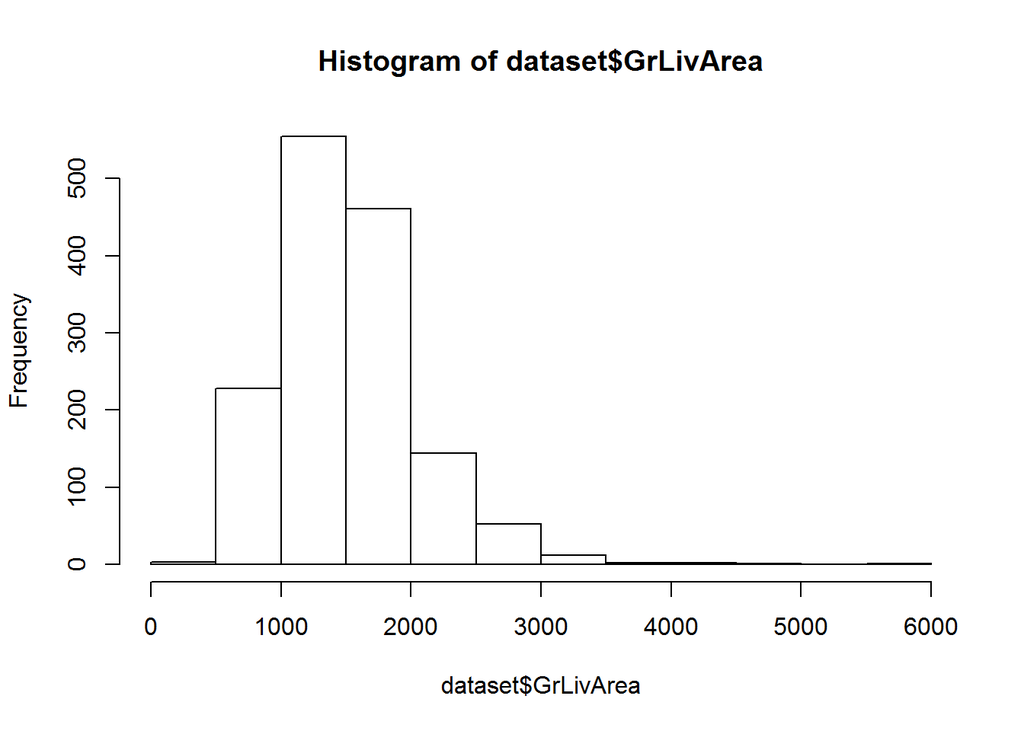

```r
#Histogram of Original Data
hist(dataset$GrLivArea)
```

```r
describe(dataset$GrLivArea)
```

```
##    vars    n    mean     sd median trimmed    mad min  max range skew
## X1    1 1460 1515.46 525.48   1464 1467.67 483.33 334 5642  5308 1.36
##    kurtosis    se
## X1     4.86 13.75
```

### Modeling.

Build some type of regression model and submit your model to the competition board. You can use as many variables as you like. Provide your complete model summary and results with analysis.

```r
attach(dataset)

model = lm(SalePrice~GrLivArea+LotArea+X1stFlrSF)
summary(model)
```

```
##
## Call:
## lm(formula = SalePrice ~ GrLivArea + LotArea + X1stFlrSF)
##
## Residuals:
##     Min      1Q  Median      3Q     Max
## -581483  -24041     820   23281  289229
##
## Coefficients:
##               Estimate Std. Error t value Pr(>|t|)
## (Intercept) -1.431e+04  4.776e+03  -2.997  0.00278 **
## GrLivArea    8.061e+01  3.192e+00  25.248  < 2e-16 ***
## LotArea      2.841e-01  1.452e-01   1.956  0.05060 .
## X1stFlrSF    6.029e+01  4.388e+00  13.739  < 2e-16 ***
## ---
## Signif. codes:  0 '***' 0.001 '**' 0.01 '*' 0.05 '.' 0.1 ' ' 1
##
## Residual standard error: 52450 on 1456 degrees of freedom
## Multiple R-squared:  0.565,  Adjusted R-squared:  0.5641
## F-statistic: 630.3 on 3 and 1456 DF,  p-value: < 2.2e-16
```

```r
#load test dataset
test_dataset = read.csv('c:/data/605/test.csv', header = TRUE)

PredictedSales = predict(model, test_dataset)
head(PredictedSales)
```

```
##        1        2        3        4        5        6
## 115228.7 176986.7 176869.4 173639.2 167451.3 167929.7
```

```r
write.csv(PredictedSales, file = "kaggle.csv")
```

First I selected variables that I thought made sence to build a multiple regression model. I added and removed several in order to improve adjusted R-squared. Next I had an issue with a number of variables which kept producing single bad estimate like negative value for Sale price or ‘NA’, so I had to trim the list of my variables down since kaggle expects a specific format so I could not just ommit “bad” entries, so I removed a big nnumber of variables, which decreased my adjusted r-squared.

My kaggle username is Joseph Elikishvili I am currently #2010 with the score of 0.26499.